# McDonald’s EDA

The EDA (Exploratory Data Analysis) on McDonald’s data revealed insights into customers purchasing patterns, and menu preferences. It provides valuable information for customers to make decisions on their dietary wants and also valuable information for strategic decision-making and targeted marketing efforts.

You can download the [dataset here](https://www.kaggle.com/datasets/mcdonalds/nutrition-facts/data)

# Packages

*Load the Packages for data manipulation and visualization*

```r
library(dplyr)
library(tidyverse)
library(GGally)
```

*Read in the data*

```r
menu <- read.csv("menu.csv")
```

### Category

The Menu Category is grouped according to the total number food items in each Category.

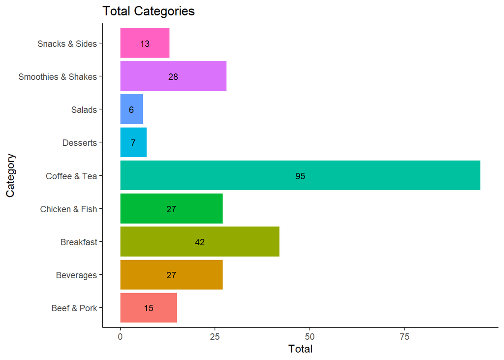

```r
cat <- menu %>%
  select(Category) %>%
  count(Category,name = "Total")  %>%
  distinct()

cat_plot <- cat %>%
  ggplot(aes(Category,
             Total,
             fill = Category)) +
  geom_col() +
  theme_classic() +
  labs(title = "Total Categories") +
  theme(legend.position = "none") +
  geom_text(aes(label = Total),
            position = position_stack(vjust = 0.5),
            color ="black", size = 3) + coord_flip()


cat_plot
```

# Protein

Proteins are made up of chemical ‘building blocks’ called amino acids. Your body uses amino acids to build and repair muscles and bones and to make hormones and enzymes. They can also be used as an energy source.

### The Average Protein Content in the Menu Category

```r
Pro_avg <- menu %>%
  select(Category,Item,Protein) %>%
  group_by(Category) %>%
  aggregate(Protein~Category,
            FUN = mean)

Pro_avg
```

| Category | Protein |
| --- | --- |
| Beef & Pork | 27.333333 |
| Beverages | 1.333333 |
| Breakfast | 19.857143 |
| Chicken & Fish | 29.111111 |
| Coffee & Tea | 8.863158 |
| Desserts | 4.000000 |
| Salads | 19.833333 |
| Smoothies & Shakes | 10.857143 |
| Snacks & Sides | 8.384615 |

### The Menu item that contains the highest amount of Protein content

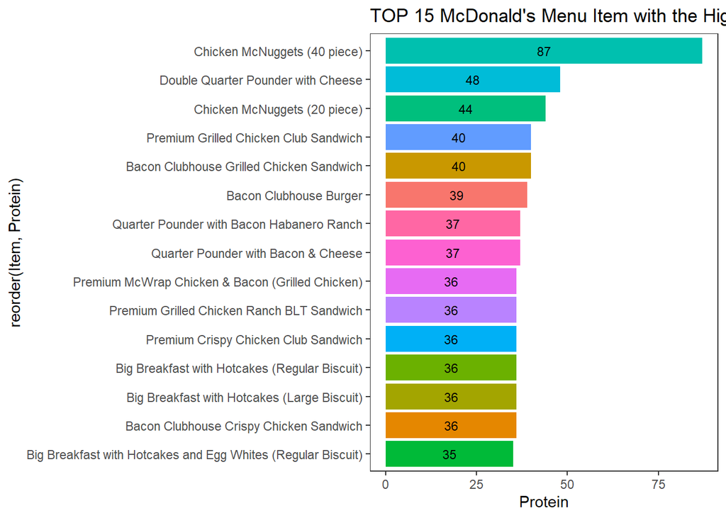

```r
max_pro <- menu %>%
  select(Item,Protein) %>%
  group_by(Item) %>%
  arrange(desc(Protein)) %>%
  head(15) %>%
  ggplot(aes(x= reorder(Item,
                        Protein),
             fill = Item)) +
  geom_bar(stat = "identity",
           aes(y= Protein )) +
  coord_flip() +
  theme_bw()+
  geom_text(aes(label = Protein,
                y= Protein),
            position = position_stack(vjust = 0.5),
            color = "Black",
            size = 3)+
  theme(legend.position="none") +
  ggtitle("TOP 15 McDonald's Menu Item with the Highest Protein Content") +theme(panel.grid.major = element_blank(), panel.grid.minor = element_blank())

max_pro
```

### What Menu item that contains the least amount of Protein content

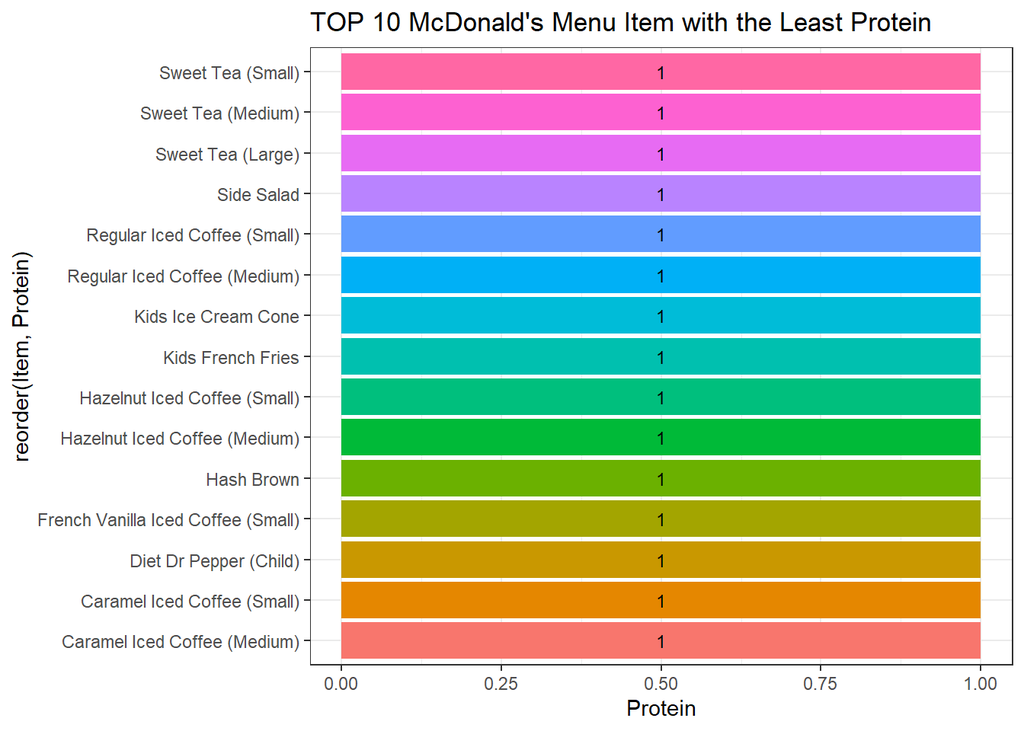

```r
min_pro <- menu %>%
  select(Item,Protein) %>%
  group_by(Item, Protein) %>%
  filter(Protein >0 )%>%
  arrange(Protein) %>%
  head(15)  %>%
  ggplot(aes(x= reorder(Item,
                        Protein),
             fill = Item)) +
  geom_bar(stat = "identity",
           aes(y= Protein )) +
  coord_flip() +
  theme_bw()+
  geom_text(aes(label = Protein,
                y= Protein),
            position = position_stack(vjust = 0.5),
            color = "Black",
            size = 3)+
  ggtitle("TOP 10 McDonald's Menu Item with the Least Protein")+
  theme(legend.position="none")

min_pro
```

# Calories

A calorie is a measure of energy. Foods have calories. That is, foods supply the body with energy, which is released when foods are broken down during digestion. Energy enables cells to do all of their functions, including building proteins and other substances needed by the body. The energy can be used immediately or stored for use later.

### The Menu Category ranked according to their Calorie Content

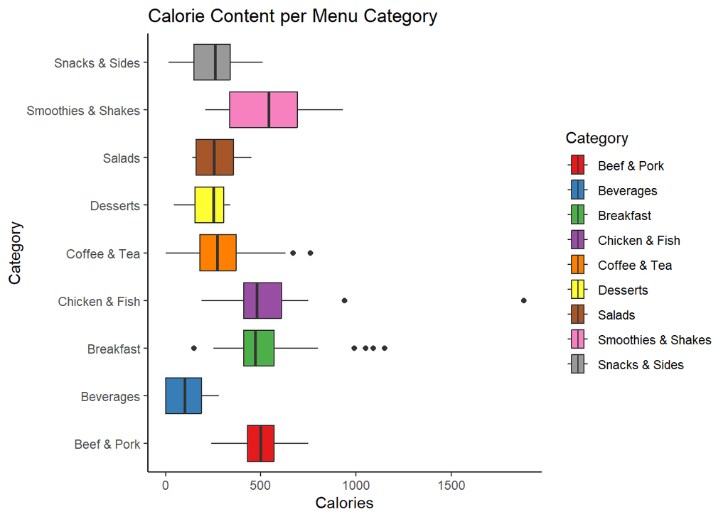

```r
cal <- menu %>%
  select(Category,
         Item,
         Calories) %>%
  group_by(Category)



cal_plot <- cal %>%
  ggplot(aes(Calories,
             Category,
             fill = Category)) +
  geom_boxplot() +
  theme_classic() +
  scale_fill_brewer(palette = "Set1") + ggtitle("Calorie Content per Menu Category")

cal_plot
```

### The Top 10 Menu Food items with High calories Content

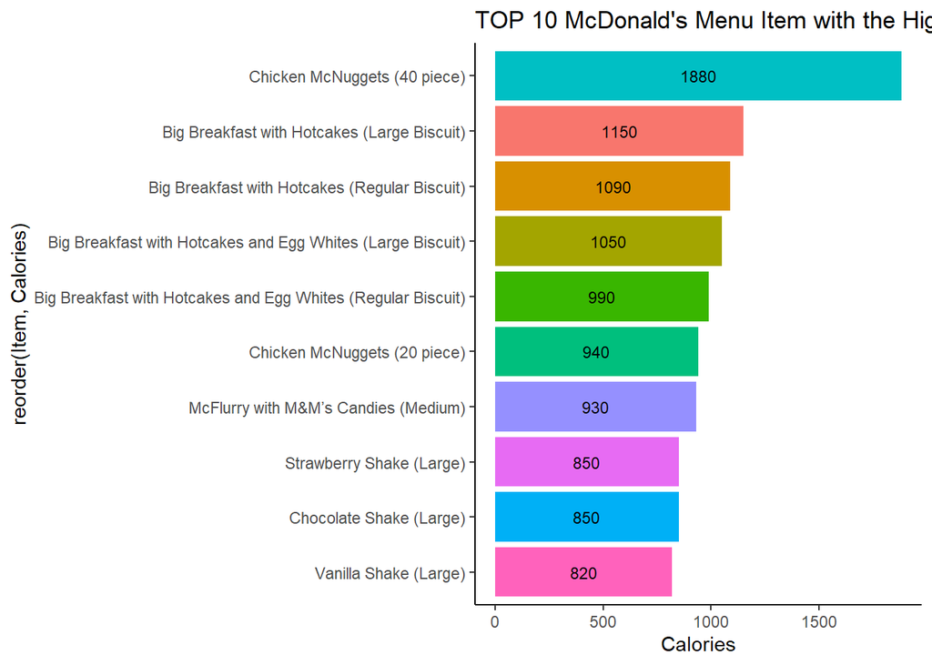

```r
max_cal <- menu %>%
  select(Category,
         Item,
         Calories) %>%
  group_by(Item) %>%
  arrange(desc(Calories))%>%
  head(10)%>%
  ggplot(aes(Calories,
             y = reorder(Item,
                         Calories)
             ,fill =Item)) +
  geom_col() +
  theme_classic()+
  theme(legend.position = "none") +
  geom_text(aes(label = Calories),
            position = position_stack(vjust = 0.5),
            color="black", size =3) + ggtitle("TOP 10 McDonald's Menu Item with the Highest Calorie Content")

max_cal
```

### The Top 10 Menu Food items with Low calories Content

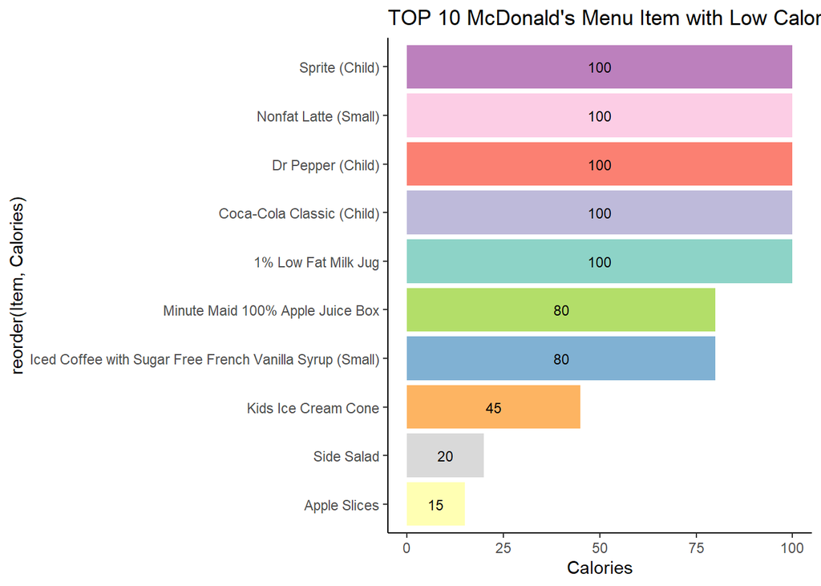

```r
min_cal <- menu %>%
  select(Category,
         Item,
         Calories)%>%
  filter(Calories>0) %>%
  group_by(Item) %>%
  arrange(Calories)%>%
  head(10) %>%
  ggplot(aes(Calories,
             y = reorder(Item,
                         Calories),
             fill =Item)) +
  geom_col() +
  theme_classic()+
  theme(legend.position = "none") +
  geom_text(aes(label = Calories),
            position = position_stack(vjust = 0.5),
            color="black", size =3) +
  scale_fill_brewer(palette = "Set3") + ggtitle("TOP 10 McDonald's Menu Item with Low Calorie Content")

min_cal
```

# Carboydrates

Carbohydrates, or carbs, are the sugars, starches, and dietary fiber that occur in certain foods. The body breaks them down into glucose, which provides energy.

### The Menu Category with the Highest Carbohydrates Content

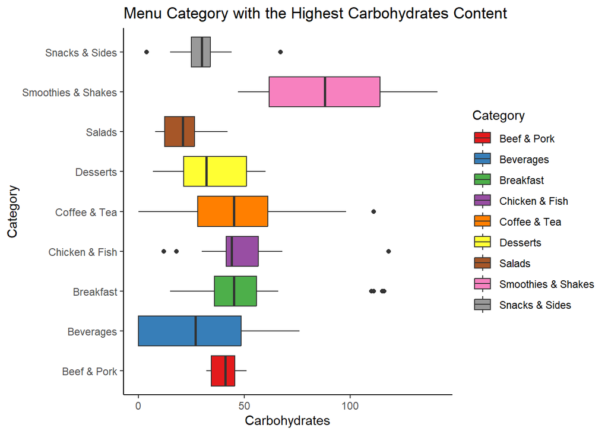

```r
carb <- menu %>%
  select(Category,
         Item,
         Carbohydrates)%>%
  group_by(Category)

carb_plot<- carb %>%
  ggplot(aes(Category,Carbohydrates,
             fill = Category)) +
  geom_boxplot() +
  scale_fill_brewer(palette = "Set1") + coord_flip() + theme_classic() + ggtitle("Menu Category with the Highest Carbohydrates Content")

carb_plot
```

## Sugar

Sugar also called simple carbohydrates occur naturally in foods, such as dairy products, as well as added sugar, which are common in baked goods, sweets, and desserts. The body very easily digests and absorbs sugar.

### The Top 10 Menu Food items with High Sugar Content

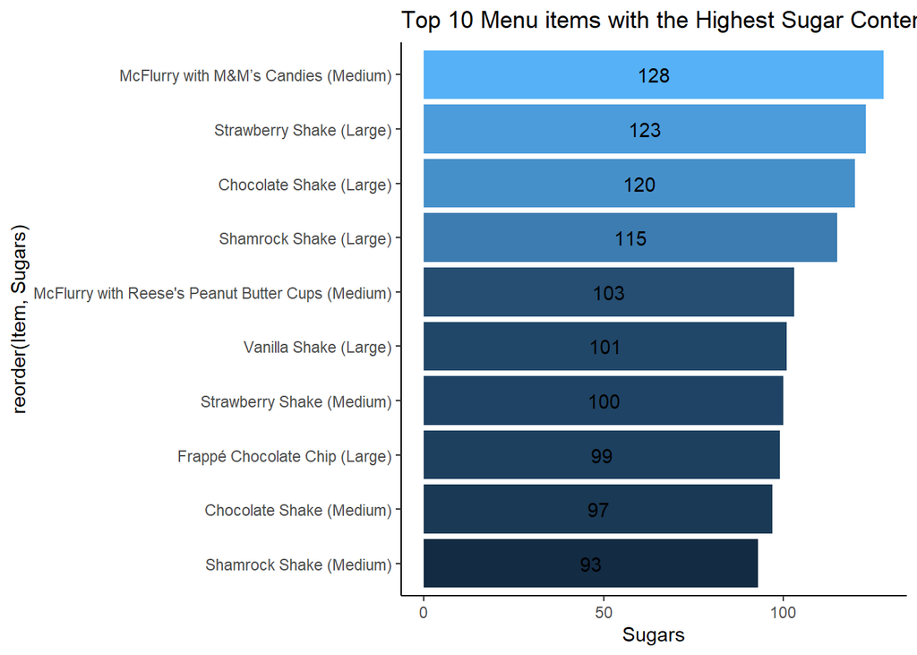

```r
sugar <- menu %>%
  select(Category,Item,Sugars) %>%
  group_by(Category)

max_sugar <-sugar %>%
  arrange(desc(Sugars)) %>%
  head(10) %>%
  ggplot(aes(Sugars,
             y=reorder(Item,
                       Sugars),
             fill = Sugars)) +
  geom_col() +
  theme_classic()+
  theme(legend.position = "none") +
  geom_text(aes(label = Sugars),
            position = position_stack(vjust = 0.5)) + ggtitle("Top 10 Menu items with the Highest Sugar Content")


max_sugar
```

### The Top 10 Menu Food items with Low Sugar Content

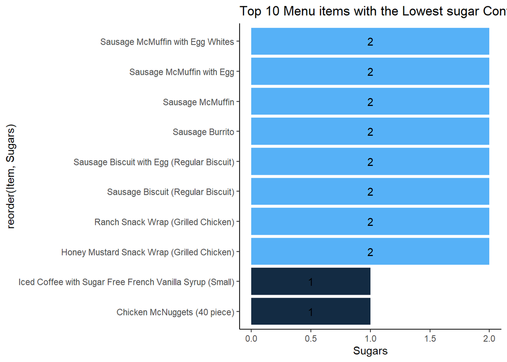

```r
min_sugar <- sugar %>%
  filter(Sugars>0) %>%
  arrange(Sugars) %>%
  head(10) %>%
  ggplot(aes(Sugars,
             y=reorder(Item,
                       Sugars),
             fill = Sugars)) +
  geom_col() +
  theme_classic()+
  theme(legend.position = "none") +
  geom_text(aes(label = Sugars),
            position = position_stack(vjust = 0.5)) + ggtitle("Top 10 Menu items with the Lowest sugar Content")


min_sugar
```

### The Menu Categories with Carbohydrates that have a higher Fibre to Sugar Ratio(Healthy Carbs)

As a general rule, the more fiber and the less sugar there is in the carbohydrate, the better it is for your body.

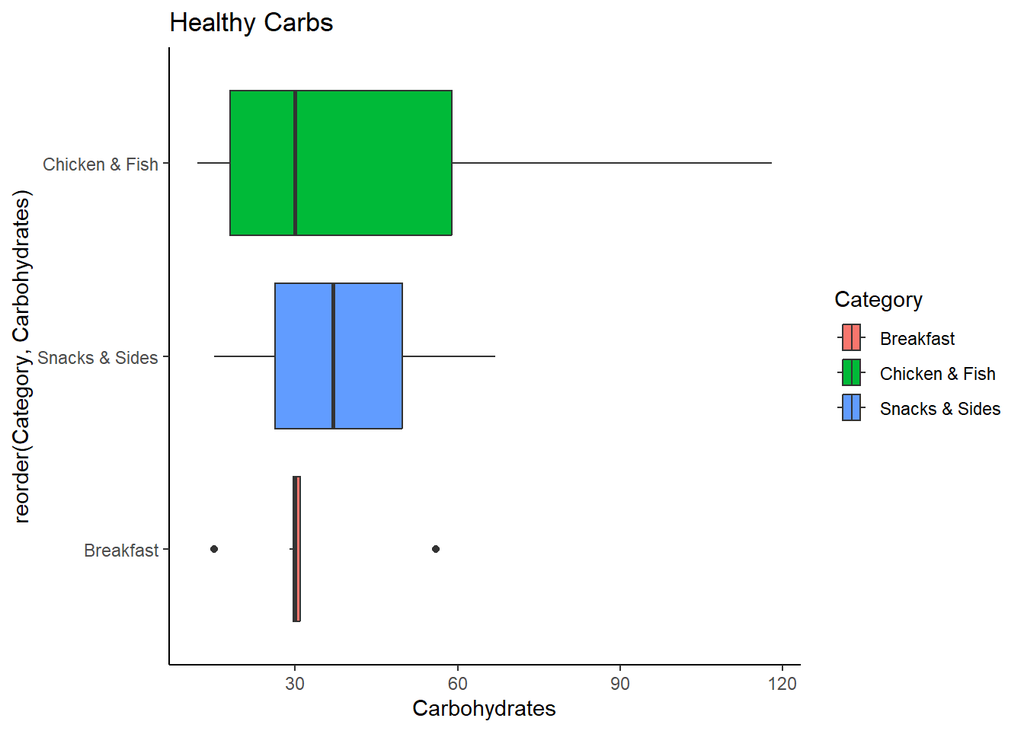

```r
healthy_carbs <-  menu %>%
  select(Carbohydrates,
         Category,
         Sugars,
         Dietary.Fiber)  %>%
  filter(Dietary.Fiber > Sugars)

healthy_carbs_plot <- healthy_carbs %>%
  ggplot(aes(Carbohydrates,
             y = reorder(Category,Carbohydrates),
             fill = Category)) +
  geom_boxplot() + ggtitle("Healthy Carbs") + theme_classic()



healthy_carbs_plot
```

### The Menu Categories grouped by sodium content

Our bodies need sodium; however, there is so much in most processed foods, and too much sodium can have several negative effects. Canned foods are notorious for having lots of sodium, as are bottled sauces, salty snacks, and processed foods. Most nutritionists recommend watching your sodium intake carefully because too much sodium in your diet is dangerous. It can lead to high blood pressure and many related health conditions.

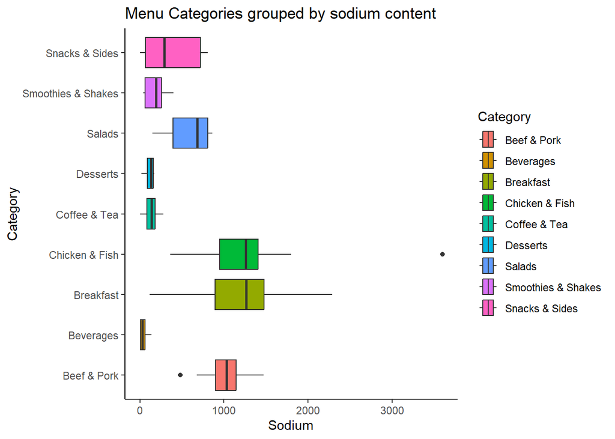

```r
sodium  <- menu %>%
  select(Category,
         Item,Sodium,
         Sodium....Daily.Value.) %>%
  group_by(Category)


sodium_plot <- sodium %>%
  ggplot(aes(Sodium,
             Category,
             fill = Category)) +
  geom_boxplot() + theme_classic() + ggtitle("Menu Categories grouped by sodium content")


sodium_plot
```

### The Menu Categories grouped by Trans Fat

In the United States, the main dietary source of trans fats is partially hydrogenated vegetable oils, previously used in many commercially prepared foods. Consuming trans fats may adversely affect cholesterol levels in the body and may contribute to the risk of atherosclerosis. Because of this, the US Food and Drug Administration (FDA) has banned the use of trans fats in prepared foods.

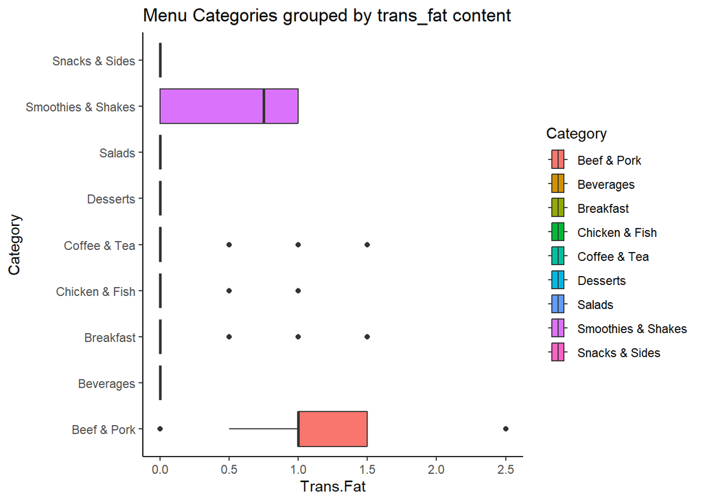

```r
trans_fat <- menu %>%
  select(Category,
         Trans.Fat) %>%
  group_by(Category)

trans_plot <- trans_fat %>%
  ggplot(aes(Trans.Fat,
             Category,
             fill = Category)) +
  geom_boxplot() + theme_classic() +  ggtitle("Menu Categories grouped by trans_fat content")

trans_plot
```

### The Correlation between Protein,Carbohydrates, Fat and Calories

Fats are the slowest source of energy but the most energy-efficient form of food.Because fats are such an efficient form of energy, the body stores any excess energy as fat.

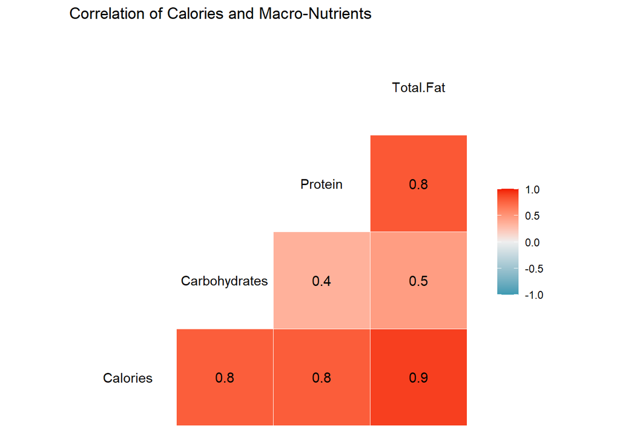

```r
calories <- menu %>%
  select(Calories,
         Carbohydrates,
         Protein,
         Total.Fat) %>%
  group_by(Calories)

calories_plot <- ggcorr(calories,
       method =  c("everything", "pearson"),
       label = TRUE)  + theme_classic() +  ggtitle("Correlation of Calories and Macro-Nutrients")

calories_plot
```